# **Problem Statement**

#### **Question 11**: Perform cluster profiling on the data using a barplot for the K-Means algorithm. Provide insights and key observations for each cluster based on the visual analysis.

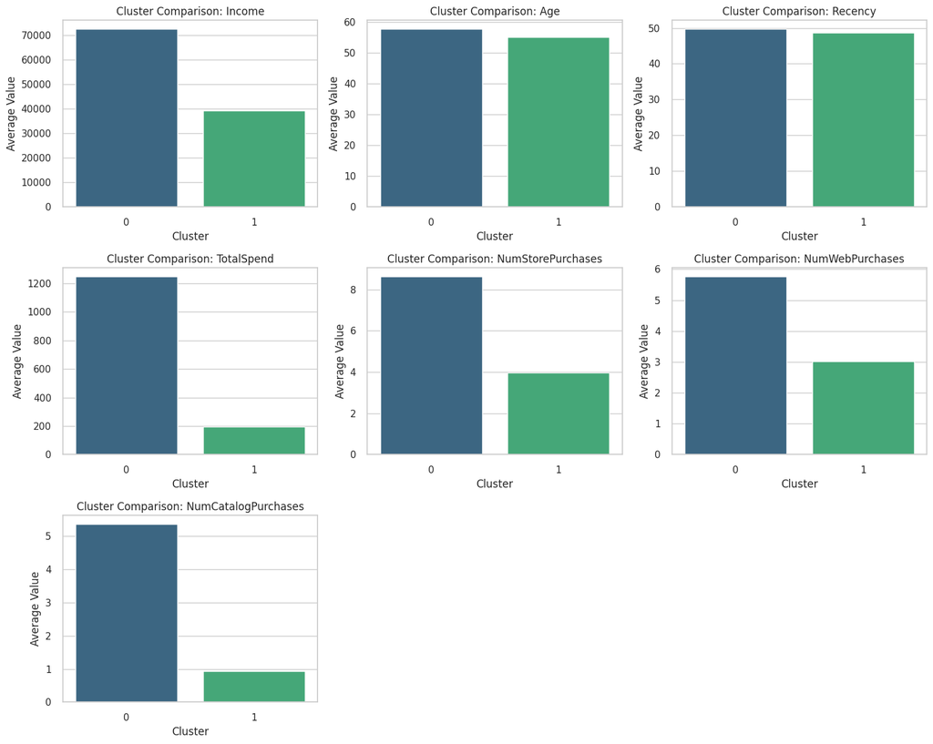

```python
import seaborn as sns
import matplotlib.pyplot as plt

# Select key features for profiling
features = ['Income', 'Age', 'Recency', 'TotalSpend',
            'NumStorePurchases', 'NumWebPurchases', 'NumCatalogPurchases']

# Set plot style
sns.set(style="whitegrid")

# Create multiple barplots
plt.figure(figsize=(15, 12))

for i, feature in enumerate(features, 1):
    plt.subplot(3, 3, i)  # 3 rows, 3 columns grid
    sns.barplot(x='Cluster', y=feature, data=data, ci=None, palette="viridis")
    plt.title(f'Cluster Comparison: {feature}')
    plt.xlabel("Cluster")
    plt.ylabel("Average Value")

plt.tight_layout()
plt.show()
```

##### **Observations:**

Income

Cluster 0 customers have much higher average income (72K) compared to Cluster 1 (39K).

Age

Both clusters are in a similar mid-50s age group.

Cluster 0 is slightly older (57.7 vs 55.2 years).

Recency (days since last purchase)

Both clusters are similar (≈49 days), meaning recency is not a strong differentiator.

Total Spend

Cluster 0 has significantly higher spending (1245) than Cluster 1 (197).

This is the strongest difference, showing Cluster 0 = high-value customers.

Store Purchases

Cluster 0 buys more often from stores (≈8.6 purchases), while Cluster 1 only ≈4 purchases.

Cluster 0 shows a clear preference for offline shopping.

Web Purchases

Cluster 0 also makes more web purchases (5.8 vs 3.0), indicating they are multi-channel shoppers.

Catalog Purchases

Cluster 0 again dominates, with ~5.3 purchases, while Cluster 1 is very low (0.9).

Suggests Cluster 0 engages across all channels, while Cluster 1 does not.

## **Business Recommedations**

#### **Question 12**: Based on the cluster insights, what business recommendations can be provided?

Cluster 0 – High-Value Multi-Channel Shoppers

Characteristics: High income, high spend, loyal, shop across store, web, and catalog. Recommendations:

Loyalty Programs – Offer exclusive memberships, rewards, and VIP benefits to retain them.

Upselling & Cross-selling – Suggest premium wines, meat, and bundled offers since they already spend a lot.

Personalized Catalogs/Offline Events – Since they engage in catalogs and store shopping, targeted catalog campaigns and private in-store events will work well.

Cluster 1 – Low-Value Limited Shoppers

Characteristics: Lower income, very low spend, higher website visits but poor conversion. Recommendations:

Digital Discounts & Flash Sales – Provide personalized online promotions to improve conversion.

Entry-Level Products – Push affordable product bundles (small wine packs, starter deals).

Engagement Campaigns – Retarget website visitors with email/SMS reminders to reduce drop-offs.

Simplify Online Journey – Optimize website UX to make checkout easier and improve conversion rate.